# Papers citing PR2

vaulot

2025-05-23

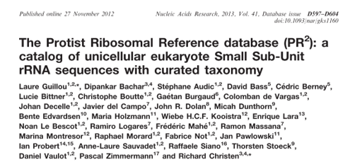

Guillou, L., Bachar, D., Audic, S., Bass, D., Berney, C., Bittner, L., Boutte, C., Burgaud, G., de Vargas, C., Decelle, J., del Campo, J., Dolan, J. R., Dunthorn, M., Edvardsen, B., Holzmann, M., Kooistra, W. H. C. F., Lara, E., Le Bescot, N., Logares, R., … Christen, R. (2013). The Protist Ribosomal Reference database (PR2): A catalog of unicellular eukaryote Small Sub-Unit rRNA sequences with curated taxonomy. Nucleic Acids Research, 41(D1), D597–D604. https://doi.org/10.1093/nar/gks1160

References are available as a [Zotero group](https://www.zotero.org/groups/2791531/pr2/library)

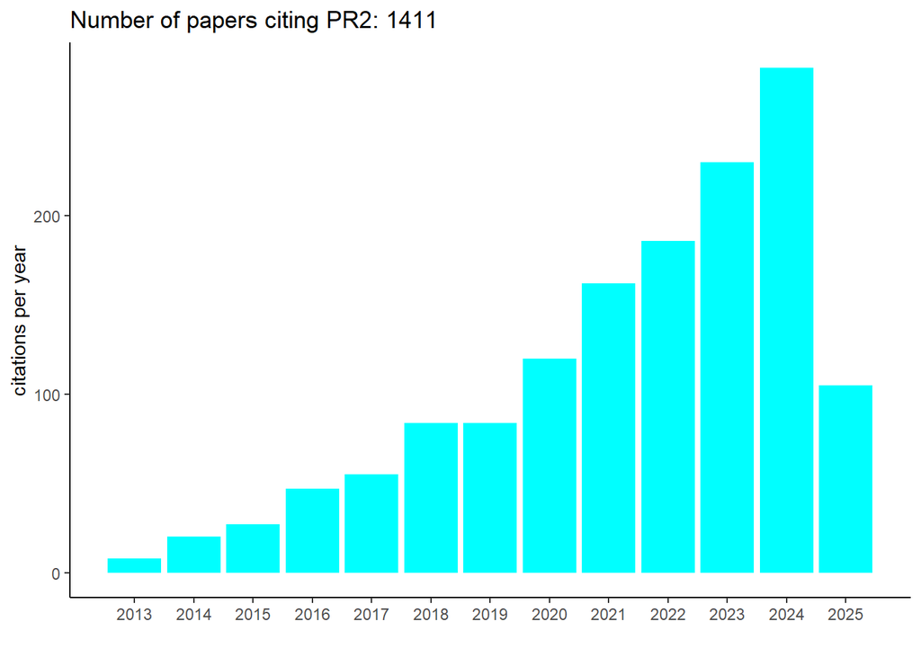

## 2025

Adyari, B., L. Zhang, A. Maravić, et al. (2025). “Urbanization enhances consumer protist-driven ARGs dissemination in riverine ecosystems”. In: *Environment International* 195. DOI: [10.1016/j.envint.2024.109238](https://doi.org/10.1016%2Fj.envint.2024.109238).

Alacid, E., A. Reñé, N. Timoneda, et al. (2025). “Macroalgal biofilm harbours a wide diversity of parasitic protists with distinct temporal dynamics”. In: *Molecular Ecology* 34.5. DOI: [10.1111/mec.17666](https://doi.org/10.1111%2Fmec.17666).

Amacker, N., Z. Gao, A. L. Jousset, et al. (2025). “Identity and timing of protist inoculation affect plant performance largely irrespective of changes in the rhizosphere microbial community”. In: *Applied and Environmental Microbiology* 91.4. DOI: [10.1128/aem.00240-25](https://doi.org/10.1128%2Faem.00240-25).

Badra, M., J. Freudenthal, and K. Dumack (2025). “Sludge retention time in anaerobic digestion affects Archaea by a cascade through microeukaryotes”. In: *Water Research* 278. DOI: [10.1016/j.watres.2025.123371](https://doi.org/10.1016%2Fj.watres.2025.123371).

Bao, Y., B. Li, R. Jia, et al. (2025). “Effects of different river crab eriocheir sinensis polyculture practices on bacterial, fungal and protist communities in pond water”. In: *Biomolecules* 15.1. DOI: [10.3390/biom15010031](https://doi.org/10.3390%2Fbiom15010031).

Bashenkhaeva, M., Y. R. Zakharova, Y. P. Galachyants, et al. (2025). “Under-ice bacterial and microeukaryotic communities of the maloe more strait (lake baikal)”. In: *Microbiology (Russian Federation)* 94.2, pp. 172 - 180. DOI: [10.1134/S002626172460890X](https://doi.org/10.1134%2FS002626172460890X).

Bludau, D., G. Sieber, M. Shah, et al. (2025). “Breaking the standard: Can oxford nanopore technologies sequencing compete with illumina in protistan amplicon studies?” In: *Environmental DNA* 7.2. DOI: [10.1002/edn3.70084](https://doi.org/10.1002%2Fedn3.70084).

Böttner, L., F. Dudenhausen, S. Nouere, et al. (2025). “Herbivory can increase plant fitness via reduced interspecific competition - evidence from models and mesocosms”. In: *Proceedings of the Royal Society B: Biological Sciences* 292.2039. DOI: [10.1098/rspb.2024.1149](https://doi.org/10.1098%2Frspb.2024.1149).

Cao, Y., Y. Lei, J. Shi, et al. (2025). “Indications of a benthic foraminifer Cribrononion gnythosuturatum to salinities revealed by eDNA metabarcoding and morphological methods”. In: *Marine Pollution Bulletin* 211. DOI: [10.1016/j.marpolbul.2024.117428](https://doi.org/10.1016%2Fj.marpolbul.2024.117428).

Casabianca, S., M. Basili, S. Capellacci, et al. (2025). “Temporal dynamics of communities on plastic debris in a polluted marine habitat”. In: *Marine Pollution Bulletin* 214. DOI: [10.1016/j.marpolbul.2025.117763](https://doi.org/10.1016%2Fj.marpolbul.2025.117763).

Chang, C., E. Hu, X. Tang, et al. (2025). “Assembly of soil multitrophic community regulates multifunctionality via multifaceted biotic factors in subtropical ecosystems”. In: *Environment International* 195. DOI: [10.1016/j.envint.2025.109272](https://doi.org/10.1016%2Fj.envint.2025.109272).

Chen, Y., J. Ning, D. Su, et al. (2025). “Molecular diversity and potential ecological risks of toxic HAB species in the coastal waters off Qinhuangdao, China”. In: *Environmental Pollution* 373. DOI: [10.1016/j.envpol.2025.126121](https://doi.org/10.1016%2Fj.envpol.2025.126121).

Connors, E., K. L. Gallagher, A. Dutta, et al. (2025). “Suspended detrital particles support a distinct microbial ecosystem in Palmer Canyon, Antarctica, a coastal biological hotspot”. In: *Polar Biology* 48.2. DOI: [10.1007/s00300-025-03380-y](https://doi.org/10.1007%2Fs00300-025-03380-y).

Dai, R., Z. Wen, H. Hong, et al. (2025). “Eukaryotic phytoplankton drive a decrease in primary production in response to elevated CO2 in the tropical and subtropical oceans”. In: *Proceedings of the National Academy of Sciences of the United States of America* 122.11. DOI: [10.1073/pnas.2423680122](https://doi.org/10.1073%2Fpnas.2423680122).

Daraghmeh, N., K. Exter, J. Pagnier, et al. (2025). “A long-term ecological research data set from the marine genetic monitoring program ARMS-MBON 2018–2020”. In: *Molecular Ecology Resources* 25.4. DOI: [10.1111/1755-0998.14073](https://doi.org/10.1111%2F1755-0998.14073).

Debnath, S. C., D. L. Chaput, J. McMurtrie, et al. (2025). “Seasonal dynamics and factors shaping microbiomes in freshwater finfish earthen aquaculture ponds in Bangladesh”. In: *Environmental Microbiome* 20.1. DOI: [10.1186/s40793-025-00687-5](https://doi.org/10.1186%2Fs40793-025-00687-5).

Du, S., D. Lin, T. Zhang, et al. (2025). “Earthworm gut’s potential positive impact on carbon cycle by influencing carbohydrate metabolism and microbial genome size”. In: *Fundamental Research*. DOI: [10.1016/j.fmre.2025.03.018](https://doi.org/10.1016%2Fj.fmre.2025.03.018).

Echenique-Subiabre, I., S. L. Jackrel, J. McCarren, et al. (2025). “Traits determine dispersal and colonization abilities of microbes”. In: *Applied and Environmental Microbiology* 91.3. DOI: [10.1128/aem.02055-24](https://doi.org/10.1128%2Faem.02055-24).

Egge, E., D. Vaulot, A. Larsen, et al. (2025). “The community of marine alveolate parasites in the Atlantic inflow to the Arctic Ocean is structured by season, depth, and water mass”. In: *Arctic Science* 11. DOI: [10.1139/as-2024-0016](https://doi.org/10.1139%2Fas-2024-0016).

Fagín, E., M. Felip, A. Brancelj, et al. (2025). “Parasite sedimentary DNA reveals fish introduction into a European high-mountain lake by the seventh century”. In: *Nature Communications* 16.1. DOI: [10.1038/s41467-025-57801-x](https://doi.org/10.1038%2Fs41467-025-57801-x).

Frigaard, N. and S. E. Seemann (2025). “Methane and CO2 consumption from a synthetic waste gas by microbial communities in enriched seawater”. In: *Carbon Capture Science and Technology* 14. DOI: [10.1016/j.ccst.2024.100324](https://doi.org/10.1016%2Fj.ccst.2024.100324).

Fukai, Y., A. Fujiwara, S. Nishino, et al. (2025). “Characteristics of autumn phytoplankton communities in the Chukchi Sea: resuspension of settled diatoms to the surface during strong wind events”. In: *Marine Ecology Progress Series* 752, pp. 35 - 50. DOI: [10.3354/meps14753](https://doi.org/10.3354%2Fmeps14753).

Fuß, T., L. Thuile Bistarelli, R. Ptacnik, et al. (2025). “Niche partitioning in a periphyton metacommunity peaks at intermediate species richness in midsized rivers”. In: *Ecology* 106.1. DOI: [10.1002/ecy.4524](https://doi.org/10.1002%2Fecy.4524).

Gerasimova, E. A., A. S. Balkin, V. Y. Kataev, et al. (2025). “Taxonomic and functional diversity of protists in saline and hypersaline lakes in southern Western Siberia, a region strongly affected by climate change”. In: *Water Biology and Security* 4.1. DOI: [10.1016/j.watbs.2024.100316](https://doi.org/10.1016%2Fj.watbs.2024.100316).

Gleich, S. J., L. Y. Mesrop, J. A. Cram, et al. (2025). “With a little help from my friends: importance of protist-protist interactions in structuring marine protistan communities in the San Pedro Channel”. In: *mSystems* 10.2. DOI: [10.1128/msystems.01045-24](https://doi.org/10.1128%2Fmsystems.01045-24).

Guo, P., C. Li, J. Liu, et al. (2025). “Contribution of environmental and biological factors to bacterial community structure and stability in a subalpine lake”. In: *Marine Life Science and Technology* 7.1, pp. 176 - 186. DOI: [10.1007/s42995-024-00256-8](https://doi.org/10.1007%2Fs42995-024-00256-8).

Hamard, S., S. Planchenault, R. Walcker, et al. (2025). “Microbial photosynthesis mitigates carbon loss from northern peatlands under warming”. In: *Nature Climate Change* 15.4, pp. 436 - 443. DOI: [10.1038/s41558-025-02271-8](https://doi.org/10.1038%2Fs41558-025-02271-8).

Hao, S., Z. Hei, J. Ma, et al. (2025). “Soil microbial diversity-function relationships are changed by human activity at a landscape scale”. In: *Plant and Soil*. DOI: [10.1007/s11104-024-07174-9](https://doi.org/10.1007%2Fs11104-024-07174-9).

Hayden, H. L., R. Ghaderi, C. Trollip, et al. (2025). “Advancing the use of metabarcoding derived nematode-based indices as soil health bioindicators in agricultural and natural environments”. In: *Soil Biology and Biochemistry* 205. DOI: [10.1016/j.soilbio.2025.109772](https://doi.org/10.1016%2Fj.soilbio.2025.109772).

Hernández-Becerril, D. U., R. Rodríguez-Martínez, F. Varona-Cordero, et al. (2025). “Diversity and distribution of the eukaryotic picoplankton in the oxygen minimum zone of the tropical Mexican Pacific”. In: *Journal of Plankton Research* 47.2. DOI: [10.1093/plankt/fbae083](https://doi.org/10.1093%2Fplankt%2Ffbae083).

Hervé, V., J. Morelle, J. Lambourdière, et al. (2025). “Together throughout the year: seasonal patterns of bacterial and eukaryotic microbial communities in a macrotidal estuary”. In: *Environmental Microbiome* 20.1. DOI: [10.1186/s40793-025-00664-y](https://doi.org/10.1186%2Fs40793-025-00664-y).

Holman, L. E., G. Zampirolo, R. Gyllencreutz, et al. (2025). “Navigating past oceans: Comparing metabarcoding and metagenomics of marine ancient sediment environmental DNA”. In: *Molecular Ecology Resources*. DOI: [10.1111/1755-0998.14086](https://doi.org/10.1111%2F1755-0998.14086).

Hu, Y., K. Jiang, S. Xia, et al. (2025). “Amoeba community dynamics and assembly mechanisms in full-scale drinking water distribution networks under various disinfectant regimens”. In: *Water Research* 271. DOI: [10.1016/j.watres.2024.122861](https://doi.org/10.1016%2Fj.watres.2024.122861).

Huang, J., J. Zhang, T. Huang, et al. (2025). “Unraveling assembly processes shaping soil protist community dynamics across successional stages of temperate forests on the Chinese Loess Plateau”. In: *Catena* 255. DOI: [10.1016/j.catena.2025.109030](https://doi.org/10.1016%2Fj.catena.2025.109030).

Huber, L., E. Malfatti, C. S. R. Huber, et al. (2025). “Is the composition of communities in bromeliad water and adjacent soil similar?” In: *Journal of Eukaryotic Microbiology* 72.3. DOI: [10.1111/jeu.70009](https://doi.org/10.1111%2Fjeu.70009).

Jeevannavar, A., J. Florenza, A. Divne, et al. (2025). “Cellular heterogeneity in metabolism and associated microbiome of a non-model phytoflagellate”. In: *ISME Journal* 19.1. DOI: [10.1093/ismejo/wraf046](https://doi.org/10.1093%2Fismejo%2Fwraf046).

Jiang, J., L. Zhou, D. Lin, et al. (2025). “Effects of multispecies management on the soil protist community in Pinus massoniana plantations in subtropical China”. In: *Pedobiologia* 109. DOI: [10.1016/j.pedobi.2025.151035](https://doi.org/10.1016%2Fj.pedobi.2025.151035).

Kaiser, P., W. Hagen, A. Schukat, et al. (2025). “Phytoplankton diversity and zooplankton diet across Fram Strait: Spatial patterns with implications for the future Arctic Ocean”. In: *Progress in Oceanography* 234. DOI: [10.1016/j.pocean.2025.103423](https://doi.org/10.1016%2Fj.pocean.2025.103423).

Kalra, I., B. P. Stewart, K. M. Florea, et al. (2025). “Temporal and spatial dynamics of harmful algal bloom-associated microbial communities in eutrophic Clear Lake, California”. In: *Applied and Environmental Microbiology* 91.4. DOI: [10.1128/aem.00011-25](https://doi.org/10.1128%2Faem.00011-25).

Kassim, N. S., L. K. Lee, K. S. Hii, et al. (2025). “Molecular diversity of benthic harmful dinoflagellates on a tropical reef: Comparing natural and artificial substrate sampling methods using DNA metabarcoding and morphological analysis”. In: *Harmful Algae* 142. DOI: [10.1016/j.hal.2024.102795](https://doi.org/10.1016%2Fj.hal.2024.102795).

Kaushik, T., V. Dixit, and R. Mohan (2025). “Spatial distribution of picoeukaryotic community from the hydrographic fronts of the indian sector of the southern ocean as revealed by metabarcoding”. In: *Polar Biology* 48.1. DOI: [10.1007/s00300-024-03319-9](https://doi.org/10.1007%2Fs00300-024-03319-9).

Klein, S. G., L. Frühe, A. J. Parry, et al. (2025). “Deep oxygen-depleted depressions in a Red Sea coral reef sustain resistant ecosystems”. In: *PNAS Nexus* 4.3. DOI: [10.1093/pnasnexus/pgaf049](https://doi.org/10.1093%2Fpnasnexus%2Fpgaf049).

Krabberød, A. K., E. Stokke, E. Thoen, et al. (2025). “The ribosomal operon database: a full-length rDNA operon database derived from genome assemblies”. In: *Molecular Ecology Resources* 25.1. DOI: [10.1111/1755-0998.14031](https://doi.org/10.1111%2F1755-0998.14031).

Lazrak, K., Z. Tazart, M. Nothof, et al. (2025). “Assessment of the short-term salinity effect on algal biofilm through field transfer in the Drâa river (Southeastern Morocco) using metabarcoding and morphological analyses”. In: *Environmental Monitoring and Assessment* 197.4. DOI: [10.1007/s10661-025-13842-9](https://doi.org/10.1007%2Fs10661-025-13842-9).

Lentendu, G., D. Singer, S. Agatha, et al. (2025). “EukFunc: a holistic eukaryotic functional reference for automated profiling of soil eukaryotes”. In: *Molecular Ecology Resources*. DOI: [10.1111/1755-0998.14118](https://doi.org/10.1111%2F1755-0998.14118).

Li, D., C. Ma, C. Yue, et al. (2025). “Windfarm construction alters soil multinutrient cycling by destabilizing microfauna community in a mountain ecosystem”. In: *Journal of Environmental Management* 373. DOI: [10.1016/j.jenvman.2024.123758](https://doi.org/10.1016%2Fj.jenvman.2024.123758).

Li, J., L. Chen, C. Zhang, et al. (2025). “Organic amendments with low C/N ratios enhanced the deposition of crop root exudates into stable soil organic carbon in a sodic soil”. In: *Plant and Soil*. DOI: [10.1007/s11104-024-07170-z](https://doi.org/10.1007%2Fs11104-024-07170-z).

Li, X., Y. Wang, M. Dunthorn, et al. (2025). “Distinct ecological processes shape micro-eukaryotic generalists and specialists in a canal-disturbed wetland, Lake Weishan, China”. In: *Water Biology and Security* 4.1. DOI: [10.1016/j.watbs.2024.100320](https://doi.org/10.1016%2Fj.watbs.2024.100320).

Li, Y. and N. Chen (2025). “Optimization and evaluation of 18S rDNA V4-based metabarcoding analysis of tripos species”. In: *Journal of Applied Phycology* 37.2, pp. 1089 - 1103. DOI: [10.1007/s10811-024-03428-2](https://doi.org/10.1007%2Fs10811-024-03428-2).

Li, Y., Y. Sun, Y. Li, et al. (2025). “Small-sized soil organisms drive the legacy of soil addition in a degraded grassland”. In: *Functional Ecology* 39.4, pp. 1031 - 1045. DOI: [10.1111/1365-2435.70019](https://doi.org/10.1111%2F1365-2435.70019).

Lian, W., W. Zhao, J. Han, et al. (2025). “Impacts of forest expansion on microbial diversity and community assembly in fragmented mountain ecosystems”. In: *Environmental Research* 270. DOI: [10.1016/j.envres.2025.120956](https://doi.org/10.1016%2Fj.envres.2025.120956).

Lian, W., W. Zhao, P. Wang, et al. (2025). “Habitat island biogeography of mountaintop plant and soil microbiomes: Similar patterns driven by different mechanisms”. In: *Global Ecology and Conservation* 59. DOI: [10.1016/j.gecco.2025.e03574](https://doi.org/10.1016%2Fj.gecco.2025.e03574).

Liao, X., H. Wang, D. Wu, et al. (2025). “Geographical and environmental factors differentially shape planktonic microbial community assembly and resistomes composition in urban rivers”. In: *Global Change Biology* 31.4. DOI: [10.1111/gcb.70211](https://doi.org/10.1111%2Fgcb.70211).

Liu, H., F. Ren, S. Wan, et al. (2025). “Nitrogen and water additions with or without mowing altered soil microbial community characteristics in a semi-arid steppe”. In: *Ecological Processes* 14.1. DOI: [10.1186/s13717-024-00568-8](https://doi.org/10.1186%2Fs13717-024-00568-8).

Luo, B., H. Hu, H. Zheng, et al. (2025). “Fertilization regulates maize nutrient use efficiency through soil rhizosphere biological network and root transcriptome”. In: *Applied Soil Ecology* 207. DOI: [10.1016/j.apsoil.2025.105912](https://doi.org/10.1016%2Fj.apsoil.2025.105912).

Mei, Z., C. Wu, S. Shi, et al. (2025). “Loss of protistan diversity weakens soil phosphorus availability”. In: *Applied Soil Ecology* 208. DOI: [10.1016/j.apsoil.2025.105976](https://doi.org/10.1016%2Fj.apsoil.2025.105976).

Mikhailov, I. S., Y. S. Bukin, A. D. Firsova, et al. (2025). “Comparison of relative and absolute abundance and biomass of freshwater phytoplankton taxa using metabarcoding and microscopy”. In: *Ecology and Evolution* 15.3. DOI: [10.1002/ece3.70856](https://doi.org/10.1002%2Fece3.70856).

Mills, D. B., A. Vuillemin, K. Muschler, et al. (2025). “The Rise of Algae promoted eukaryote predation in the Neoproterozoic benthos”. In: *Science Advances* 11.8. DOI: [10.1126/sciadv.adt2147](https://doi.org/10.1126%2Fsciadv.adt2147).

Mitrović, M., A. Čačković, L. Selak, et al. (2025). “A preliminary study on the eukaryotic microbial diversity in croatian geothermal waters”. In: *Water (Switzerland)* 17.4. DOI: [10.3390/w17040541](https://doi.org/10.3390%2Fw17040541).

Neri, F., M. Ubaldi, S. Accoroni, et al. (2025). “Comparative analysis of phytoplankton diversity using microscopy and metabarcoding: insights from an eLTER station in the Northern Adriatic Sea”. In: *Hydrobiologia* 852.1, pp. 169 - 183. DOI: [10.1007/s10750-024-05692-2](https://doi.org/10.1007%2Fs10750-024-05692-2).

Neupane, S., T. Davis, C. Olds, et al. (2025). “Unraveling the relationships between midge abundance and incidence, microbial communities, and soil and water properties in a protected natural tallgrass prairie”. In: *Parasites and Vectors* 18.1. DOI: [10.1186/s13071-025-06780-5](https://doi.org/10.1186%2Fs13071-025-06780-5).

Ong, D. R. Y., A. Gutiérrez-Rodríguez, K. A. Safi, et al. (2025). “Consistent cell-specific carbon fixation rates by small eukaryotic phytoplankton in contrasting nutrient-limited conditions”. In: *Limnology and Oceanography* 70.1, pp. 162 - 177. DOI: [10.1002/lno.12751](https://doi.org/10.1002%2Flno.12751).

Pagnier, J., N. Daraghmeh, and M. Obst (2025). “Using the long-term genetic monitoring network ARMS-MBON to detect marine non-indigenous species along the European coasts”. In: *Biological Invasions* 27.2. DOI: [10.1007/s10530-024-03503-2](https://doi.org/10.1007%2Fs10530-024-03503-2).

Park, J., B. L. Muhammad, T. Kim, et al. (2025). “Assessment of ship hull-attached marine diatoms: species composition and reattachment”. In: *Marine Pollution Bulletin* 216. DOI: [10.1016/j.marpolbul.2025.117962](https://doi.org/10.1016%2Fj.marpolbul.2025.117962).

Pelusi, A., M. L. R. Martínez, A. Mule, et al. (2025). “Diatom distribution and long-term survival in a heavily polluted sediment core from the Bay of Bagnoli (Tyrrhenian Sea, Italy)”. In: *Mediterranean Marine Science* 26.1, pp. 40 - 54. DOI: [10.12681/mms.37946](https://doi.org/10.12681%2Fmms.37946).

Pérez-Barrancos, C., E. Fraile-Nuez, J. P. Martín-Díaz, et al. (2025). “Shallow hydrothermal fluids shape microbial dynamics at the tagoro submarine volcano (canary islands, spain)”. In: *Environmental Microbiology* 27.2. DOI: [10.1111/1462-2920.70052](https://doi.org/10.1111%2F1462-2920.70052).

Piwosz, K., A. Ameryk, K. Wdówka, et al. (2025). “Vertical distribution of heterotrophic nanoflagellates in the Baltic Proper”. In: *Oceanologia* 67.1. DOI: [10.5697/JMZS3739](https://doi.org/10.5697%2FJMZS3739).

Ren, P., A. Sun, X. Jiao, et al. (2025). “The relationship between protist consumers and soil functional genes under long-term fertilization”. In: *Science of the Total Environment* 966. DOI: [10.1016/j.scitotenv.2025.178658](https://doi.org/10.1016%2Fj.scitotenv.2025.178658).

Ren, X., C. Liu, Y. Yue, et al. (2025). “Exploring the potential role of soil protists in predicting banana health”. In: *Microbiological Research* 295. DOI: [10.1016/j.micres.2025.128109](https://doi.org/10.1016%2Fj.micres.2025.128109).

Salis, R. and L. Hansson (2025). “Comparative analysis of environmental DNA metabarcoding and spectro-fluorescence for phytoplankton community assessments”. In: *Environmental DNA* 7.2. DOI: [10.1002/edn3.70097](https://doi.org/10.1002%2Fedn3.70097).

Schalch-Schuler, M., B. Bassin, A. Andrei, et al. (2025). “The planktonic freshwater ciliate Balanion planctonicum (Ciliophora, Prostomatea): A cryptic species complex or a “complex species”?” In: *Journal of Eukaryotic Microbiology* 72.1. DOI: [10.1111/jeu.13084](https://doi.org/10.1111%2Fjeu.13084).

Shimonaka, T., T. Kodama, S. Otosaka, et al. (2025). “Differences in sinking processes and biological pump contribution among phytoplankton groups in the mesopelagic layer”. In: *Global Biogeochemical Cycles* 39.4. DOI: [10.1029/2024GB008476](https://doi.org/10.1029%2F2024GB008476).

Sidón-Ceseña, K., M. A. Martínez-Mercado, J. Chong-Robles, et al. (2025). “The protist community of the oligotrophic waters of the Gulf of Mexico is distinctly shaped by depth-specific physicochemical conditions during the warm season”. In: *FEMS Microbiology Ecology* 101.2. DOI: [10.1093/femsec/fiaf009](https://doi.org/10.1093%2Ffemsec%2Ffiaf009).

Sow, S. L. S., W. H. van de Poll, R. Eveleth, et al. (2025). “Spatial and temporal variation of Antarctic microbial interactions: a study around the west Antarctic Peninsula”. In: *Environmental Microbiome* 20.1. DOI: [10.1186/s40793-025-00663-z](https://doi.org/10.1186%2Fs40793-025-00663-z).

Stewart, J., N. M. de Lima, D. J. Eldridge, et al. (2025). “Restoring aboveground trophic diversity contributes to belowground microbial diversity in drylands”. In: *Biological Conservation* 305. DOI: [10.1016/j.biocon.2025.111056](https://doi.org/10.1016%2Fj.biocon.2025.111056).

Stock, W., C. Rousseau, G. Dierickx, et al. (2025). “Breaking free from references: a consensus-based approach for community profiling with long amplicon nanopore data”. In: *Briefings in Bioinformatics* 26.1. DOI: [10.1093/bib/bbae642](https://doi.org/10.1093%2Fbib%2Fbbae642).

Sun, Y., L. Tang, Y. Cui, et al. (2025). “Inoculation of plant growth-promoting rhizobacteria and rhizobia changes the protist community of alfalfa rhizosphere soil under saline-alkali environment”. In: *Applied Soil Ecology* 206. DOI: [10.1016/j.apsoil.2024.105775](https://doi.org/10.1016%2Fj.apsoil.2024.105775).

Sweetlove, M., B. Tytgat, E. Van de Vyver, et al. (2025). “Differences in community structuring among planktonic bacterial and micro-eukaryotic phyla in Chilean freshwater lakes”. In: *Limnologica (Online)* 111. DOI: [10.1016/j.limno.2025.126233](https://doi.org/10.1016%2Fj.limno.2025.126233).

Tapolczai, K., F. Rimet, M. Ćirić, et al. (2025). “A novel framework for phytoplankton biomonitoring: Trait assignment of 23S rRNA sequences”. In: *Ecological Indicators* 173. DOI: [10.1016/j.ecolind.2025.113361](https://doi.org/10.1016%2Fj.ecolind.2025.113361).

Tian, M., Z. Zhao, Q. Li, et al. (2025). “Nanoscale phosphorus-based agrochemicals enhance tomato and rice growth via positively modulating the growth-associated gene expression and endophytic microbial community”. In: *Environmental Science: Nano*. DOI: [10.1039/d5en00140d](https://doi.org/10.1039%2Fd5en00140d).

TONG, Y., L. WANG, C. WU, et al. (2025). “Promotion of symbiotic interaction between phagotrophic protists and beneficial bacteria, mediated via a balancing of soil nutrients, reduces the incidence of watermelon Fusarium wilt”. In: *Pedosphere* 35.2, pp. 352 - 363. DOI: [10.1016/j.pedsph.2023.12.014](https://doi.org/10.1016%2Fj.pedsph.2023.12.014).

Tong, Y., X. Zheng, H. Liu, et al. (2025). “Bio-organic fertilizer enhances soil mineral solubilization, microbial community stability, and fruit quality in an 8-year watermelon continuous cropping system”. In: *Biology and Fertility of Soils* 61.4, pp. 747 - 760. DOI: [10.1007/s00374-025-01892-7](https://doi.org/10.1007%2Fs00374-025-01892-7).

Tucker, S. J., Y. M. Rii, K. C. Freel, et al. (2025). “Seasonal and spatial transitions in phytoplankton assemblages spanning estuarine to open ocean waters of the tropical Pacific”. In: *Limnology and Oceanography*. DOI: [10.1002/lno.70075](https://doi.org/10.1002%2Flno.70075).

Vader, A., E. Handler, R. Skogseth, et al. (2025). “Seasonality and interannual variability of an Arctic marine time series, IsA”. In: *Arctic Science* 11, pp. 1 - 17. DOI: [10.1139/as-2024-0044](https://doi.org/10.1139%2Fas-2024-0044).

Varrella, S., S. Livi, C. Corinaldesi, et al. (2025). “A comprehensive assessment of non-indigenous species requires the combination of multi-marker eDNA metabarcoding with classical taxonomic identification”. In: *Environment International* 199. DOI: [10.1016/j.envint.2025.109489](https://doi.org/10.1016%2Fj.envint.2025.109489).

Verdon, V., L. Malard, F. Collart, et al. (2025). “Can we accurately predict the distribution of soil microorganism presence and relative abundance?” In: *Ecography* 2025.3. DOI: [10.1111/ecog.07086](https://doi.org/10.1111%2Fecog.07086).

Wang, H., K. Liu, Z. He, et al. (2025). “Rich molecular diversity of ribosomal RNA genes in Pseudo-nitzschia species (Bacillariophyceae) revealed through single-strain high throughput sequencing”. In: *Algal Research* 85. DOI: [10.1016/j.algal.2024.103869](https://doi.org/10.1016%2Fj.algal.2024.103869).

Wang, H., J. Yang, D. R. Finn, et al. (2025). “Distinct seasonal and annual variability of prokaryotes, fungi and protists in cropland soil under different tillage systems and soil texture”. In: *Soil Biology and Biochemistry* 203. DOI: [10.1016/j.soilbio.2025.109732](https://doi.org/10.1016%2Fj.soilbio.2025.109732).

Wang, L., X. Du, W. Shen, et al. (2025). “Inter-trophic networks reveal the central role of methanogens in deposited estuarine soils”. In: *Soil Ecology Letters* 7.2. DOI: [10.1007/s42832-025-0295-1](https://doi.org/10.1007%2Fs42832-025-0295-1).

Wang, X., F. Chen, J. Zeng, et al. (2025). “Divergent responses of soil glomalin and microbial necromass to precipitation reduction: New perspectives from soil aggregates and multi-trophic networks”. In: *Soil Biology and Biochemistry* 200. DOI: [10.1016/j.soilbio.2024.109638](https://doi.org/10.1016%2Fj.soilbio.2024.109638).

Wieber, C., L. Z. Jensen, L. Vergeynst, et al. (2025). “Terrestrial runoff is an important source of biological ice-nucleating particles in Arctic marine systems”. In: *Atmospheric Chemistry and Physics* 25.6, pp. 3327 - 3346. DOI: [10.5194/acp-25-3327-2025](https://doi.org/10.5194%2Facp-25-3327-2025).

Willemsen, A., A. Manzano-Marín, and M. Horn (2025). “Novel high-quality amoeba genomes reveal widespread codon usage mismatch between giant viruses and their hosts”. In: *Genome Biology and Evolution* 17.1. DOI: [10.1093/gbe/evae271](https://doi.org/10.1093%2Fgbe%2Fevae271).

Wittmers, F., C. Poirier, C. Bachy, et al. (2025). “Symbionts of predatory protists are widespread in the oceans and related to animal pathogens”. In: *Cell Host and Microbe* 33.2, pp. 182 - 199.e7. DOI: [10.1016/j.chom.2025.01.009](https://doi.org/10.1016%2Fj.chom.2025.01.009).

Wu, F., F. Li, Y. Zou, et al. (2025). “Environmental DNA reveals multitrophic insight into the mechanism of community stability changes in shallow eutrophic lakes”. In: *ACS ES and T Water*. DOI: [10.1021/acsestwater.4c01064](https://doi.org/10.1021%2Facsestwater.4c01064).

Xu, H., X. He, J. Chen, et al. (2025). “Soil nutrient limitation controls trophic cascade effects of micro-food web-derived ecological functions in degraded agroecosystems”. In: *Journal of Advanced Research*. DOI: [10.1016/j.jare.2025.01.018](https://doi.org/10.1016%2Fj.jare.2025.01.018).

Xu, M., X. Liu, T. Chen, et al. (2025). “Dynamics of wheat rhizosphere microbiome and its impact on grain production across growth stages”. In: *Science of the Total Environment* 964. DOI: [10.1016/j.scitotenv.2025.178524](https://doi.org/10.1016%2Fj.scitotenv.2025.178524).

Xu, Q., M. Feng, B. He, et al. (2025). “Soil micro-structure drives trophic interactions within micro-food webs via bottom-up regulation under different planting patterns”. In: *Agriculture, Ecosystems and Environment* 383. DOI: [10.1016/j.agee.2025.109539](https://doi.org/10.1016%2Fj.agee.2025.109539).

Xu, W., C. Lam, Y. Wang, et al. (2025). “Temporal succession of marine microbes drives plastisphere community convergence in subtropical coastal waters”. In: *Environmental Pollution* 367. DOI: [10.1016/j.envpol.2024.125572](https://doi.org/10.1016%2Fj.envpol.2024.125572).

Yu, Y., M. Shangguan, P. Sun, et al. (2025). “Light-mediated population dynamics of picocyanobacteria shaping the diurnal patterns of microbial communities in an atoll lagoon”. In: *Microorganisms* 13.4. DOI: [10.3390/microorganisms13040727](https://doi.org/10.3390%2Fmicroorganisms13040727).

Záhonová, K., H. Kaur, C. C. Furgason, et al. (2025). “Comparative analysis of protist communities in oilsands tailings using amplicon sequencing and metagenomics”. In: *Environmental Microbiology* 27.1. DOI: [10.1111/1462-2920.70029](https://doi.org/10.1111%2F1462-2920.70029).

Zhang, A., A. M. Potapov, R. Luo, et al. (2025). “Protist communities are correlated with abiotic soil factors, but not resources, prey, or predators along a subalpine secondary succession”. In: *Geoderma* 458. DOI: [10.1016/j.geoderma.2025.117310](https://doi.org/10.1016%2Fj.geoderma.2025.117310).

Zhang, W., Y. Zhang, Z. Shao, et al. (2025). “Differences in biogeographic patterns and mechanisms of assembly in estuarine bacterial and protist communities”. In: *Microorganisms* 13.1. DOI: [10.3390/microorganisms13010214](https://doi.org/10.3390%2Fmicroorganisms13010214).

Zhao, R., Y. Shi, L. Huang, et al. (2025). “Dynamics of protist and bacterial communities during the nitrogen removal by ecological floating beds of Sesuvium portulacastrum”. In: *Ecological Processes* 14.1. DOI: [10.1186/s13717-025-00602-3](https://doi.org/10.1186%2Fs13717-025-00602-3).

Zhu, H., K. Fazliddin, Q. Li, et al. (2025). “Contrasting adaptations of soil prokaryotes and arbuscular mycorrhizal fungi in saline wildland and non-saline farmland”. In: *Fundamental Research*. DOI: [10.1016/j.fmre.2025.02.009](https://doi.org/10.1016%2Fj.fmre.2025.02.009).

Zuo, J., S. Yang, H. Grossart, et al. (2025). “Sequential decline in cyanobacterial, total prokaryotic, and eukaryotic responses to backward flow in a river connected to Lake Taihu”. In: *Water Research* 269. DOI: [10.1016/j.watres.2024.122784](https://doi.org/10.1016%2Fj.watres.2024.122784).

## 2024

Ahme, A., A. Happe, M. Striebel, et al. (2024). “Warming increases the compositional and functional variability of a temperate protist community”. In: *Science of the Total Environment* 926. DOI: [10.1016/j.scitotenv.2024.171971](https://doi.org/10.1016%2Fj.scitotenv.2024.171971).

Ahmed, M., D. Slos, and O. Holovachov (2024). “Assessing the diversity of nematodes in the store mosse national park (sweden) using metabarcoding”. In: *Metabarcoding and Metagenomics* 8. DOI: [10.3897/mbmg.8.111307](https://doi.org/10.3897%2Fmbmg.8.111307).

Alonzo, K. H. F. and A. O. Lluisma (2024). “Molecular detection and first report of gyrodinium jinhaense (dinophyceae, alveolata) in a tropical river-estuary system”. In: *Philippine Journal of Science* 153.5, pp. 1731 - 1738.

Ariyadasa, S., S. van Hamelsveld, W. Taylor, et al. (2024). “Diversity of free-living amoebae in new zealand groundwater and their ability to feed on legionella pneumophila”. In: *Pathogens (Basel, Switzerland)* 13.8. DOI: [10.3390/pathogens13080665](https://doi.org/10.3390%2Fpathogens13080665).

Atteia, A., B. Bec, C. Gianaroli, et al. (2024). “Evaluation of sequential filtration and centrifugation to capture environmental DNA and survey microbial eukaryotic communities in aquatic environments”. In: *Molecular Ecology Resources* 24.1. DOI: [10.1111/1755-0998.13887](https://doi.org/10.1111%2F1755-0998.13887).

Aylagas, E., H. Shchepanik, J. K. Pearman, et al. (2024). “Disentangling eukaryotic biodiversity patterns from man-made environments (port and marina) and nearby coral reefs in the Red Sea: A focus on the surveillance of non-indigenous species”. In: *Environmental DNA* 6.4. DOI: [10.1002/edn3.583](https://doi.org/10.1002%2Fedn3.583).

Baek, S. H., C. H. Lee, J. S. Park, et al. (2024). “Temporal changes in microalgal biomass and species composition on different plastic polymers in nutrient-enriched microcosm experiments”. In: *Science of the Total Environment* 946. DOI: [10.1016/j.scitotenv.2024.174352](https://doi.org/10.1016%2Fj.scitotenv.2024.174352).

Bairoliya, S., J. Koh, Z. T. Cho, et al. (2024). “Phototrophs as the central components of the plastisphere microbiome in coastal environments”. In: *Environment International* 190. DOI: [10.1016/j.envint.2024.108901](https://doi.org/10.1016%2Fj.envint.2024.108901).

Barbosa, M., F. W. Lefler, D. E. Berthold, et al. (2024). “Macrophyte coverage drives microbial community structure and interactions in a shallow sub-tropical lake”. In: *Science of the Total Environment* 923. DOI: [10.1016/j.scitotenv.2024.171414](https://doi.org/10.1016%2Fj.scitotenv.2024.171414).

Baricevic, A., T. Kogovsek, M. Smodlaka Tankovic, et al. (2024). “Coastal eukaryotic plankton diversity of the southern adriatic as revealed by metabarcoding”. In: *Diversity* 16.5. DOI: [10.3390/d16050293](https://doi.org/10.3390%2Fd16050293).

Barta, B., A. Szabó, B. Szabó, et al. (2024). “How pondscapes function: connectivity matters for biodiversity even across small spatial scales in aquatic metacommunities”. In: *Ecography* 2024.2. DOI: [10.1111/ecog.06960](https://doi.org/10.1111%2Fecog.06960).

Battie-Laclau, P., A. Taudière, M. Bernard, et al. (2024). “Terroir and farming practices drive arbuscular mycorrhizal fungal communities in French vineyards”. In: *Frontiers in Microbiology* 15. DOI: [10.3389/fmicb.2024.1463326](https://doi.org/10.3389%2Ffmicb.2024.1463326).

Bergman, I., E. S. Lindström, and I. Sassenhagen (2024). “Ciliate grazing on the bloom-forming microalga gonyostomum semen”. In: *Microbial Ecology* 87.1. DOI: [10.1007/s00248-024-02344-9](https://doi.org/10.1007%2Fs00248-024-02344-9).

Blackman, R., M. Couton, F. Keck, et al. (2024). “Environmental DNA: The next chapter”. In: *Molecular Ecology* 33.11. DOI: [10.1111/mec.17355](https://doi.org/10.1111%2Fmec.17355).

Blais, M., A. Matveev, C. Lovejoy, et al. (2024). “Size-dependent community patterns differ between microbial eukaryotes and bacteria in a permafrost lake–river–sea continuum”. In: *Limnology and Oceanography* 69.3, pp. 667 - 680. DOI: [10.1002/lno.12511](https://doi.org/10.1002%2Flno.12511).

Blais, M., W. F. Vincent, A. Vigneron, et al. (2024). “Diverse winter communities and biogeochemical cycling potential in the under-ice microbial plankton of a subarctic river-to-sea continuum”. In: *Microbiology Spectrum* 12.5. DOI: [10.1128/spectrum.04160-23](https://doi.org/10.1128%2Fspectrum.04160-23).

Bodur, S. O., S. O. Samuel, K. Suzuki, et al. (2024). “Nitrogen-based fertilizers differentially affect protist community composition in paddy field soils”. In: *Soil Ecology Letters* 6.3. DOI: [10.1007/s42832-023-0221-3](https://doi.org/10.1007%2Fs42832-023-0221-3).

Bonacolta, A. M., J. Miravall, D. Gómez-Gras, et al. (2024). “Differential apicomplexan presence predicts thermal stress mortality in the Mediterranean coral Paramuricea clavata”. In: *Environmental Microbiology* 26.1. DOI: [10.1111/1462-2920.16548](https://doi.org/10.1111%2F1462-2920.16548).

Bonacolta, A. M., P. T. Visscher, J. del Campo, et al. (2024). “The eukaryome of modern microbialites reveals distinct colonization across aquatic ecosystems”. In: *npj Biofilms and Microbiomes* 10.1. DOI: [10.1038/s41522-024-00547-z](https://doi.org/10.1038%2Fs41522-024-00547-z).

Borbee, E. M., I. A. Puspa, E. R. E. Gelis, et al. (2024). “Surface currents shape protist community structure across the Indo-Pacific”. In: *Journal of Phycology* 60.4, pp. 816 - 833. DOI: [10.1111/jpy.13465](https://doi.org/10.1111%2Fjpy.13465).

Brown, K. M., K. B. Barker, R. S. Wagner, et al. (2024). “Bacterial community and cyanotoxin gene distribution of the winam gulf, lake victoria, kenya”. In: *Environmental Microbiology Reports* 16.3. DOI: [10.1111/1758-2229.13297](https://doi.org/10.1111%2F1758-2229.13297).

Brown, M. V., M. Ostrowski, L. F. Messer, et al. (2024). “A marine heatwave drives significant shifts in pelagic microbiology”. In: *Communications Biology* 7.1. DOI: [10.1038/s42003-023-05702-4](https://doi.org/10.1038%2Fs42003-023-05702-4).

C.-Dupont, A. Ö., D. Rosado-Porto, I. S. Sundaram, et al. (2024). “Elevated atmospheric co2 levels impact soil protist functional core community compositions”. In: *Current Microbiology* 81.12. DOI: [10.1007/s00284-024-03930-3](https://doi.org/10.1007%2Fs00284-024-03930-3).

Campello-Nunes, P. H., I. D. da Silva-Neto, T. da S. Paiva, et al. (2024). “Ciliate diversity in rodrigo de freitas lagoon (Rio de Janeiro, Brazil) from an integrative standpoint”. In: *Brazilian Journal of Microbiology* 55.2, pp. 1489 - 1505. DOI: [10.1007/s42770-024-01291-4](https://doi.org/10.1007%2Fs42770-024-01291-4).

Campese, L., L. Russo, M. Abagnale, et al. (2024). “The NEREA Augmented Observatory: an integrative approach to marine coastal ecology”. In: *Scientific Data* 11.1. DOI: [10.1038/s41597-024-03787-y](https://doi.org/10.1038%2Fs41597-024-03787-y).

Camuy-Vélez, L. A., S. Banerjee, and K. Sedivec (2024). “Grazing intensity alters network complexity and predator-prey relationships in the soil microbiome”. In: *Applied and Environmental Microbiology* 90.10. DOI: [10.1128/aem.00425-24](https://doi.org/10.1128%2Faem.00425-24).

Carve, M., T. Manning, A. Mouradov, et al. (2024). “eDNA metabarcoding reveals biodiversity and depth stratification patterns of dinoflagellate assemblages within the epipelagic zone of the western Coral Sea”. In: *BMC Ecology and Evolution* 24.1. DOI: [10.1186/s12862-024-02220-7](https://doi.org/10.1186%2Fs12862-024-02220-7).

Catlett, D., E. E. Peacock, D. N. Fontaine, et al. (2024). “Concurrent DNA meta-barcoding and plankton imaging reveal novel parasitic infection and competition in a diatom”. In: *Limnology and Oceanography*. DOI: [10.1002/lno.12629](https://doi.org/10.1002%2Flno.12629).

Charalampous, G., K. A. Kormas, E. Antoniou, et al. (2024). “Distinct communities of bacteria and unicellular eukaryotes in the different water masses of cretan passage water column (eastern mediterranean sea)”. In: *Current Microbiology* 81.11. DOI: [10.1007/s00284-024-03906-3](https://doi.org/10.1007%2Fs00284-024-03906-3).

Chase, E., T. Pitot, S. Bouchard, et al. (2024). “Viral dynamics in a high-rate algal pond reveals a burst of Phycodnaviridae diversity correlated with episodic algal mortality”. In: *mBio* 15.12. DOI: [10.1128/mbio.02803-24](https://doi.org/10.1128%2Fmbio.02803-24).

Che, T., X. Zhang, M. He, et al. (2024). “Common vetch intercropping with reduced irrigation ensures potato production by optimizing microbial interactions”. In: *Field Crops Research* 307. DOI: [10.1016/j.fcr.2024.109267](https://doi.org/10.1016%2Fj.fcr.2024.109267).

Chelliah, D. S., A. E. Ray, E. Zhang, et al. (2024). “The Vestfold Hills are alive: characterising microbial and environmental dynamics in Old Wallow, eastern Antarctica”. In: *Frontiers in Microbiology* 15. DOI: [10.3389/fmicb.2024.1443491](https://doi.org/10.3389%2Ffmicb.2024.1443491).

Chen, W., Y. Lin, S. Tsai, et al. (2024). “Diversity and distribution of small-sized planktonic ciliate communities in the East China Sea”. In: *Frontiers in Marine Science* 11. DOI: [10.3389/fmars.2024.1349707](https://doi.org/10.3389%2Ffmars.2024.1349707).

Chen, Z., T. Gu, and J. Sun (2024). “Dispersed limitation and homogeneous selection drive the eukaryotic microbial community assembly and network stability in the coastal China sea”. In: *Frontiers in Marine Science* 11. DOI: [10.3389/fmars.2024.1444870](https://doi.org/10.3389%2Ffmars.2024.1444870).

Cheng, Z., Q. Han, Y. He, et al. (2024). “Contrasting response of rice rhizosphere microbiomes to in situ cadmium-contaminated soil remediation”. In: *Soil Ecology Letters* 6.2. DOI: [10.1007/s42832-023-0203-5](https://doi.org/10.1007%2Fs42832-023-0203-5).

Cho, A., D. V. Tikhonenkov, G. Lax, et al. (2024). “Phylogenomic position of genetically diverse phagotrophic stramenopile flagellates in the sediment-associated MAST-6 lineage and a potentially halotolerant placididean”. In: *Molecular Phylogenetics and Evolution* 190. DOI: [10.1016/j.ympev.2023.107964](https://doi.org/10.1016%2Fj.ympev.2023.107964).

Chrismas, N., B. Tindall-Jones, H. Jenkins, et al. (2024). “Metatranscriptomics reveals diversity of symbiotic interaction and mechanisms of carbon exchange in the marine cyanolichen Lichina pygmaea”. In: *New Phytologist* 241.5, pp. 2243 - 2257. DOI: [10.1111/nph.19320](https://doi.org/10.1111%2Fnph.19320).

Connors, E., L. Lebreton, J. S. Bowman, et al. (2024). “Changes in microbial community structure of bio-fouled polyolefins over a year-long seawater incubation in Hawai’i”. In: *Environmental Microbiology Reports* 16.4. DOI: [10.1111/1758-2229.13283](https://doi.org/10.1111%2F1758-2229.13283).

Coubris, C., K. Mirzaei, L. Duchatelet, et al. (2024). “Availability and occurrence of coelenterazine in a Swedish fjord to maintain Amphiura filiformis bioluminescence”. In: *Scientific Reports* 14.1. DOI: [10.1038/s41598-024-82811-y](https://doi.org/10.1038%2Fs41598-024-82811-y).

Cristi, A., C. S. Law, M. Pinkerton, et al. (2024). “Environmental driving forces and phytoplankton diversity across the Ross Sea region during a summer–autumn transition”. In: *Limnology and Oceanography* 69.4, pp. 772 - 788. DOI: [10.1002/lno.12526](https://doi.org/10.1002%2Flno.12526).

Cubillos, C. F., P. Aguilar, D. Moreira, et al. (2024). “Exploring the prokaryote-eukaryote interplay in microbial mats from an Andean athalassohaline wetland”. In: *Microbiology Spectrum* 12.4. DOI: [10.1128/spectrum.00072-24](https://doi.org/10.1128%2Fspectrum.00072-24).

Cui, H., S. Chen, H. Song, et al. (2024). “Contrasting mechanisms of non-vascular and vascular plants on spatial turnover in multifunctionality in the Antarctic continent”. In: *Journal of Ecology* 112.7, pp. 1624 - 1637. DOI: [10.1111/1365-2745.14346](https://doi.org/10.1111%2F1365-2745.14346).

Curd, E. E., L. Gal, R. Gallego, et al. (2024). “rCRUX: A rapid and versatile tool for generating metabarcoding reference libraries in R”. In: *Environmental DNA* 6.1. DOI: [10.1002/edn3.489](https://doi.org/10.1002%2Fedn3.489).

Degrune, F., K. Dumack, M. Ryo, et al. (2024). “The impact of fungi on soil protist communities in European cereal croplands”. In: *Environmental Microbiology* 26.7. DOI: [10.1111/1462-2920.16673](https://doi.org/10.1111%2F1462-2920.16673).

Deutschmann, I. M., E. Delage, C. R. Giner, et al. (2024). “Disentangling microbial networks across pelagic zones in the tropical and subtropical global ocean”. In: *Nature Communications* 15.1. DOI: [10.1038/s41467-023-44550-y](https://doi.org/10.1038%2Fs41467-023-44550-y).

Dong, K., Y. Wang, W. Zhang, et al. (2024). “Prevalence and preferred niche of small eukaryotes with mixotrophic potentials in the global ocean”. In: *Microorganisms* 12.4. DOI: [10.3390/microorganisms12040750](https://doi.org/10.3390%2Fmicroorganisms12040750).

Dong, L., M. Li, S. Li, et al. (2024). “Aridity drives the variability of desert soil microbiomes across north-western China”. In: *Science of the Total Environment* 907. DOI: [10.1016/j.scitotenv.2023.168048](https://doi.org/10.1016%2Fj.scitotenv.2023.168048).

Du, S., X. Li, L. Bi, et al. (2024). “Stochastic community assembly of abundant taxa maintains the relationship of soil biodiversity-multifunctionality under mercury stress”. In: *Soil Ecology Letters* 6.2. DOI: [10.1007/s42832-023-0197-z](https://doi.org/10.1007%2Fs42832-023-0197-z).

Eckmann, C. A., C. Bachy, F. Wittmers, et al. (2024). “Recurring seasonality exposes dominant species and niche partitioning strategies of open ocean picoeukaryotic algae”. In: *Communications Earth and Environment* 5.1. DOI: [10.1038/s43247-024-01395-7](https://doi.org/10.1038%2Fs43247-024-01395-7).

Edwards, K. F., Y. M. Rii, Q. Li, et al. (2024). “Trophic strategies of picoeukaryotic phytoplankton vary over time and with depth in the North Pacific Subtropical Gyre”. In: *Environmental Microbiology* 26.8. DOI: [10.1111/1462-2920.16689](https://doi.org/10.1111%2F1462-2920.16689).

Fang, K., Y. Kou, N. Tang, et al. (2024). “Differential responses of soil bacteria, fungi and protists to root exudates and temperature”. In: *Microbiological Research* 286. DOI: [10.1016/j.micres.2024.127829](https://doi.org/10.1016%2Fj.micres.2024.127829).

Fang, K., N. Tang, J. Liu, et al. (2024). “The influence of soil factors on protist community dynamics during plant succession in subalpine natural and planted forests”. In: *Soil Biology and Biochemistry* 191. DOI: [10.1016/j.soilbio.2024.109365](https://doi.org/10.1016%2Fj.soilbio.2024.109365).

Flo, S., C. Svensen, K. Præbel, et al. (2024). “Dietary plasticity in small Arctic copepods as revealed with prey metabarcoding”. In: *Journal of Plankton Research* 46.5, pp. 500 - 514. DOI: [10.1093/plankt/fbae042](https://doi.org/10.1093%2Fplankt%2Ffbae042).

Flo, S., A. Vader, and K. Præbel (2024). “Brute force prey metabarcoding to explore the diets of small invertebrates”. In: *Ecology and Evolution* 14.5. DOI: [10.1002/ece3.11369](https://doi.org/10.1002%2Fece3.11369).

Florenza, J., A. Divne, and S. Bertilsson (2024). “Fluorescently labeled prey surrogates in combination with fluorescence-activated cell sorting successfully discriminate actively feeding mixotrophs in a lake water sample”. In: *Limnology and Oceanography* 69.5, pp. 1030 - 1044. DOI: [10.1002/lno.12545](https://doi.org/10.1002%2Flno.12545).

Freudenthal, J., K. Dumack, S. Schaffer, et al. (2024). “Algae-fungi symbioses and bacteria-fungi co-exclusion drive tree species-specific differences in canopy bark microbiomes”. In: *ISME Journal* 18.1. DOI: [10.1093/ismejo/wrae206](https://doi.org/10.1093%2Fismejo%2Fwrae206).

Fromm, A., G. Hevroni, F. Vincent, et al. (2024). “Single-cell RNA-seq of the rare virosphere reveals the native hosts of giant viruses in the marine environment”. In: *Nature Microbiology* 9.6, pp. 1619 - 1629. DOI: [10.1038/s41564-024-01669-y](https://doi.org/10.1038%2Fs41564-024-01669-y).

Fu, Y., Z. Qu, Y. Wang, et al. (2024). “Biogeographical and biodiversity patterns of planktonic microeukaryotes along the tropical western to eastern Pacific Ocean transect revealed by metabarcoding”. In: *Microbiology Spectrum* 12.4. DOI: [10.1128/spectrum.02424-23](https://doi.org/10.1128%2Fspectrum.02424-23).

Fuß, T., L. Thuile Bistarelli, F. Walther, et al. (2024). “Geodiversity of a European river network controls algal biodiversity and function”. In: *Communications Earth and Environment* 5.1. DOI: [10.1038/s43247-024-01478-5](https://doi.org/10.1038%2Fs43247-024-01478-5).

Gad, M., M. Yosri, M. E. Fawzy, et al. (2024). “Microeukaryotic communities diversity with a special emphasis on protozoa taxa in an integrated wastewater treatment system”. In: *Environmental Sciences Europe* 36.1. DOI: [10.1186/s12302-024-00907-8](https://doi.org/10.1186%2Fs12302-024-00907-8).

Gao, M., C. Xiong, C. K. M. Tsui, et al. (2024). “Pathogen invasion increases the abundance of predatory protists and their prey associations in the plant microbiome”. In: *Molecular Ecology* 33.3. DOI: [10.1111/mec.17228](https://doi.org/10.1111%2Fmec.17228).

Gao, X., K. Chen, J. Xiong, et al. (2024). “The P10K database: a data portal for the protist 10 000 genomes project”. In: *Nucleic Acids Research* 52.D1, pp. D747 - D755. DOI: [10.1093/nar/gkad992](https://doi.org/10.1093%2Fnar%2Fgkad992).

Gaonkar, C. C. and L. Campbell (2024). “A full-length 18S ribosomal DNA metabarcoding approach for determining protist community diversity using Nanopore sequencing”. In: *Ecology and Evolution* 14.4. DOI: [10.1002/ece3.11232](https://doi.org/10.1002%2Fece3.11232).

Geng, X., Y. Liu, W. Xu, et al. (2024). “Eukaryotes may play an important ecological role in the gut microbiome of Graves’ disease”. In: *Frontiers in Immunology* 15. DOI: [10.3389/fimmu.2024.1334158](https://doi.org/10.3389%2Ffimmu.2024.1334158).

Genitsaris, S., N. Stefanidou, D. Hatzinikolaou, et al. (2024). “Marine microbiota responses to shipping scrubber effluent assessed at community structure and function endpoints”. In: *Environmental Toxicology and Chemistry* 43.5, pp. 1012 - 1029. DOI: [10.1002/etc.5834](https://doi.org/10.1002%2Fetc.5834).

Girard, E. B., E. A. Didaskalou, A. M. A. Pratama, et al. (2024). “Quantitative assessment of reef foraminifera community from metabarcoding data”. In: *Molecular Ecology Resources* 24.7. DOI: [10.1111/1755-0998.14000](https://doi.org/10.1111%2F1755-0998.14000).

Gleich, S. J., S. K. Hu, A. I. Krinos, et al. (2024). “Protistan community composition and metabolism in the North Pacific Subtropical Gyre: Influences of mesoscale eddies and depth”. In: *Environmental Microbiology* 26.1. DOI: [10.1111/1462-2920.16556](https://doi.org/10.1111%2F1462-2920.16556).

Gogoleva, N. E., M. A. Nasyrova, A. S. Balkin, et al. (2024). “Flourishing in darkness: Protist communities of water sites in shulgan-tash cave (southern urals, russia)”. In: *Diversity* 16.9. DOI: [10.3390/d16090526](https://doi.org/10.3390%2Fd16090526).

Gong, F., S. Huang, W. Xie, et al. (2024). “Effects of tidal cycles on the variability of microbial communities in a semiclosed bay”. In: *Continental Shelf Research* 272. DOI: [10.1016/j.csr.2023.105147](https://doi.org/10.1016%2Fj.csr.2023.105147).

Grant, D. M., K. Steinsland, T. Cordier, et al. (2024). “Sedimentary ancient DNA sequences reveal marine ecosystem shifts and indicator taxa for glacial-interglacial sea ice conditions”. In: *Quaternary Science Reviews* 339. DOI: [10.1016/j.quascirev.2024.108619](https://doi.org/10.1016%2Fj.quascirev.2024.108619).

Gu, H., J. Zheng, S. Huang, et al. (2024). “A new dinoflagellate Gonyaulax pospelovana with resting cysts resembling Spiniferites delicatus and its biogeography and ecology revealed by DNA metabarcoding”. In: *Phycologia* 63.1, pp. 74 - 88. DOI: [10.1080/00318884.2023.2293311](https://doi.org/10.1080%2F00318884.2023.2293311).

Gu, S., S. Wu, W. Zeng, et al. (2024). “High-elevation-induced decrease in soil pH weakens ecosystem multifunctionality by influencing soil microbiomes”. In: *Environmental Research* 257. DOI: [10.1016/j.envres.2024.119330](https://doi.org/10.1016%2Fj.envres.2024.119330).

Gu, Y., S. Lin, Y. Mo, et al. (2024). “Niche features and assembly mechanisms of microeukaryotic generalists and specialists along a north–south gradient of a subtropical coastal sea”. In: *Marine Ecology Progress Series* 742, pp. 35 - 57. DOI: [10.3354/meps14647](https://doi.org/10.3354%2Fmeps14647).

Guan, Y., F. Bak, R. C. Hennessy, et al. (2024). “The potential of Pseudomonas fluorescens SBW25 to produce viscosin enhances wheat root colonization and shapes root-associated microbial communities in a plant genotype-dependent manner in soil systems”. In: *mSphere* 9.7. DOI: [10.1128/msphere.00294-24](https://doi.org/10.1128%2Fmsphere.00294-24).

Guo, S., S. Geisen, Y. Mo, et al. (2024). “Predatory protists impact plant performance by promoting plant growth-promoting rhizobacterial consortia”. In: *ISME Journal* 18.1. DOI: [10.1093/ismejo/wrae180](https://doi.org/10.1093%2Fismejo%2Fwrae180).

Guo, S., Z. Jiao, Z. Yan, et al. (2024). “Predatory protists reduce bacteria wilt disease incidence in tomato plants”. In: *Nature Communications* 15.1. DOI: [10.1038/s41467-024-45150-0](https://doi.org/10.1038%2Fs41467-024-45150-0).

Hao, Y., C. Lu, Q. Xiang, et al. (2024). “Unveiling the overlooked microbial niches thriving on building exteriors”. In: *Environment International* 187. DOI: [10.1016/j.envint.2024.108649](https://doi.org/10.1016%2Fj.envint.2024.108649).

Hao, Y., A. Sun, C. Lu, et al. (2024). “Protists and fungi: Reinforcing urban soil ecological functions against flash droughts”. In: *Science of the Total Environment* 950. DOI: [10.1016/j.scitotenv.2024.175274](https://doi.org/10.1016%2Fj.scitotenv.2024.175274).

He, P., A. Sun, X. Jiao, et al. (2024). “National-scale distribution of protists associated with sorghum leaves and roots”. In: *Environmental Microbiology Reports* 16.5. DOI: [10.1111/1758-2229.70024](https://doi.org/10.1111%2F1758-2229.70024).

He, Z., H. Hu, B. Thi Nguyen, et al. (2024). “Distribution of soil tardigrades as revealed by molecular identification across a large-scale area of Australia”. In: *Soil Biology and Biochemistry* 196. DOI: [10.1016/j.soilbio.2024.109506](https://doi.org/10.1016%2Fj.soilbio.2024.109506).

He, Z., S. Liu, Z. Cui, et al. (2024). “Metabarcoding analysis of the composition and spatial–temporal dynamics of Pseudo-nitzschia species in Jiaozhou Bay, China”. In: *Journal of Applied Phycology* 36.1, pp. 259 - 272. DOI: [10.1007/s10811-023-03127-4](https://doi.org/10.1007%2Fs10811-023-03127-4).

Head, M. J., K. N. Mertens, and R. A. Fensome (2024). “Dual nomenclature in organic-walled dinoflagellate cysts I: concepts, methods and applications”. In: *Palynology* 48.2. DOI: [10.1080/01916122.2023.2290200](https://doi.org/10.1080%2F01916122.2023.2290200).

Hemkemeyer, M., S. A. Schwalb, C. Berendonk, et al. (2024). “Potato yield and quality are linked to cover crop and soil microbiome, respectively”. In: *Biology and Fertility of Soils* 60.4, pp. 525 - 545. DOI: [10.1007/s00374-024-01813-0](https://doi.org/10.1007%2Fs00374-024-01813-0).

Hii, K. S., A. H. N. Abdul Manaff, H. Gu, et al. (2024). “A comparative analysis of real-time quantitative PCR and metabarcoding methods for eDNA-based detection of the toxic dinophyte Alexandrium tamiyavanichii (Dinophyceae)”. In: *Marine Environmental Research* 199. DOI: [10.1016/j.marenvres.2024.106593](https://doi.org/10.1016%2Fj.marenvres.2024.106593).

Hirai, J., S. Katakura, H. Kasai, et al. (2024). “Ecological interactions between marine RNA viruses and planktonic copepods”. In: *Communications Biology* 7.1. DOI: [10.1038/s42003-024-07189-z](https://doi.org/10.1038%2Fs42003-024-07189-z).

Holzmann, M., N. Nguyen, I. B. Angeles, et al. (2024). “BFR2: a curated ribosomal reference dataset for benthic foraminifera”. In: *Scientific Data* 11.1. DOI: [10.1038/s41597-024-04137-8](https://doi.org/10.1038%2Fs41597-024-04137-8).

Hooper, P. M., D. Bass, E. J. Feil, et al. (2024). “Arctic cyanobacterial mat community diversity decreases with latitude across the Canadian Arctic”. In: *FEMS Microbiology Ecology* 100.6. DOI: [10.1093/femsec/fiae067](https://doi.org/10.1093%2Ffemsec%2Ffiae067).

Hou, D., H. Yan, H. Lin, et al. (2024). “Biogeographic shifts in the microbial co-occurrence network features of three domains across complex environmental gradients in subtropical coastal waters”. In: *Ecological Processes* 13.1. DOI: [10.1186/s13717-024-00550-4](https://doi.org/10.1186%2Fs13717-024-00550-4).

Hou, S., T. Tang, S. Cheng, et al. (2024). “DeepMicroClass sorts metagenomic contigs into prokaryotes, eukaryotes and viruses”. In: *NAR Genomics and Bioinformatics* 6.2. DOI: [10.1093/nargab/lqae044](https://doi.org/10.1093%2Fnargab%2Flqae044).

Hou, Y., Y. Zhang, R. Jia, et al. (2024). “Variations in the bacterial, fungal, and protist communities and their interactions within sediment affected by the benthic organism, snail bellamya purificata”. In: *Microorganisms* 12.12. DOI: [10.3390/microorganisms12122550](https://doi.org/10.3390%2Fmicroorganisms12122550).

Hu, S. K., R. E. Anderson, M. G. Pachiadaki, et al. (2024). “Microbial eukaryotic predation pressure and biomass at deep-sea hydrothermal vents”. In: *ISME Journal* 18.1. DOI: [10.1093/ismejo/wrae004](https://doi.org/10.1093%2Fismejo%2Fwrae004).

Hu, X., H. Gu, J. Liu, et al. (2024). “Different long-term fertilization regimes affect soil protists and their top-down control on bacterial and fungal communities in Mollisols”. In: *Science of the Total Environment* 908. DOI: [10.1016/j.scitotenv.2023.168049](https://doi.org/10.1016%2Fj.scitotenv.2023.168049).

Huang, X., Y. Li, H. Du, et al. (2024). “Comparative assessment of the intragenomic variations of dinoflagellate Tripos species through single-cell sequencing”. In: *Marine Pollution Bulletin* 206. DOI: [10.1016/j.marpolbul.2024.116690](https://doi.org/10.1016%2Fj.marpolbul.2024.116690).

Huang, X., K. Liu, X. Ding, et al. (2024). “Dinoflagellate Tripos species composition and seasonal dynamics in Jiaozhou Bay revealed through 18S rDNA V4-based metabarcoding analysis”. In: *Journal of Applied Phycology* 36.4, pp. 1939 - 1952. DOI: [10.1007/s10811-024-03239-5](https://doi.org/10.1007%2Fs10811-024-03239-5).

Huang, X., J. Wang, K. Dumack, et al. (2024). “Temperature-dependent trophic associations modulate soil bacterial communities along latitudinal gradients”. In: *ISME Journal* 18.1. DOI: [10.1093/ismejo/wrae145](https://doi.org/10.1093%2Fismejo%2Fwrae145).

Huber, P., D. De Angelis, H. Sarmento, et al. (2024). “Global distribution, diversity, and ecological niche of Picozoa, a widespread and enigmatic marine protist lineage”. In: *Microbiome* 12.1. DOI: [10.1186/s40168-024-01874-1](https://doi.org/10.1186%2Fs40168-024-01874-1).

Hylander, S., H. Farnelid, E. Fridolfsson, et al. (2024). “Thiamin (vitamin B1, thiamine) transfer in the aquatic food web from lower to higher trophic levels”. In: *PLoS ONE* 19.12. DOI: [10.1371/journal.pone.0308844](https://doi.org/10.1371%2Fjournal.pone.0308844).

Jackson, V. L. N., T. Grevesse, E. S. Kilias, et al. (2024). “Vulnerability of Arctic Ocean microbial eukaryotes to sea ice loss”. In: *Scientific Reports* 14.1. DOI: [10.1038/s41598-024-77821-9](https://doi.org/10.1038%2Fs41598-024-77821-9).

Jacquemot, L., J. Tremblay, C. Morency, et al. (2024). “Stratification and summer protist communities in the Arctic influenced coastal systems of Nunavik (Québec, Canada)”. In: *Frontiers in Marine Science* 11. DOI: [10.3389/fmars.2024.1321604](https://doi.org/10.3389%2Ffmars.2024.1321604).

James, C. C., A. E. Allen, R. H. Lampe, et al. (2024). “Endemic, cosmopolitan, and generalist taxa and their habitat affinities within a coastal marine microbiome”. In: *Scientific Reports* 14.1. DOI: [10.1038/s41598-024-69991-3](https://doi.org/10.1038%2Fs41598-024-69991-3).

Jeanbille, M., S. Romdhane, M. Breuil, et al. (2024). “Size exclusion experiment in a grassland field unravels top–down control of the soil fauna on microbial community assembly”. In: *Ecology Letters* 27.6. DOI: [10.1111/ele.14442](https://doi.org/10.1111%2Fele.14442).

Jeevannavar, A., A. Narwani, B. Matthews, et al. (2024). “Foundation species stabilize an alternative eutrophic state in nutrient-disturbed ponds via selection on microbial community”. In: *Frontiers in Microbiology* 15. DOI: [10.3389/fmicb.2024.1310374](https://doi.org/10.3389%2Ffmicb.2024.1310374).

Jia, C., G. Zhou, X. Qiu, et al. (2024). “Straw addition promotes the nitrification process and the wheat yield linked to trophic interactions among microbes”. In: *European Journal of Soil Science* 75.2. DOI: [10.1111/ejss.13467](https://doi.org/10.1111%2Fejss.13467).

Jiang, P., Y. Zhou, K. Yang, et al. (2024). “Biodiversity and network complexity of rhizosphere soil microbiomes regulate the differentiation of Capsicum growth strategies”. In: *Plant and Soil*. DOI: [10.1007/s11104-024-06862-w](https://doi.org/10.1007%2Fs11104-024-06862-w).

Jung, P., R. Brand, L. Briegel-Williams, et al. (2024). “The symbiotic alga Trebouxia fuels a coherent soil ecosystem on the landscape scale in the Atacama Desert”. In: *Environmental Microbiome* 19.1. DOI: [10.1186/s40793-024-00601-5](https://doi.org/10.1186%2Fs40793-024-00601-5).

Kajan, K., B. M. Fuchs, and S. Orlić (2024). “Insight into planktonic protistan and fungal communities across the nutrient-depleted environment of the South Pacific Subtropical Gyre”. In: *Microbiology Spectrum* 12.3. DOI: [10.1128/spectrum.03016-23](https://doi.org/10.1128%2Fspectrum.03016-23).

Kang, Z., Z. Lei, W. Fei, et al. (2024). “Dynamics in eukaryotic algal communities regulate bacterial and fungal communities as biocrusts develop in a temperate desert in Central Asia”. In: *Functional Ecology* 38.3, pp. 531 - 545. DOI: [10.1111/1365-2435.14496](https://doi.org/10.1111%2F1365-2435.14496).

Karlicki, M., A. Bednarska, P. Hałakuc, et al. (2024). “Spatio-temporal changes of small protist and free-living bacterial communities in a temperate dimictic lake: Insights from metabarcoding and machine learning”. In: *FEMS Microbiology Ecology* 100.8. DOI: [10.1093/femsec/fiae104](https://doi.org/10.1093%2Ffemsec%2Ffiae104).

Katzenmeier, S. N., M. Nothof, H. Breiner, et al. (2024). “Mesoscale cyclonic eddies born in an eastern boundary upwelling system enhance microbial eukaryote diversity in oligotrophic offshore waters”. In: *Deep-Sea Research Part II: Topical Studies in Oceanography* 218. DOI: [10.1016/j.dsr2.2024.105425](https://doi.org/10.1016%2Fj.dsr2.2024.105425).

Kaushik, T. and V. Dixit (2024). “Environmental DNA (eDNA) dataset of foraminiferal diversity and distribution from the mining-impacted estuaries of Goa, west coast of India”. In: *Data in Brief* 54. DOI: [10.1016/j.dib.2024.110541](https://doi.org/10.1016%2Fj.dib.2024.110541).

Kibet, S., C. M. Mudalungu, N. M. Kimani, et al. (2024). “Unearthing Lactococcus lactis and Scheffersomyeces symbionts from edible wood-boring beetle larvae as a bio-resource for industrial applications”. In: *BMC Microbiology* 24.1. DOI: [10.1186/s12866-024-03428-9](https://doi.org/10.1186%2Fs12866-024-03428-9).

Kilner, C. L., A. A. Carrell, D. J. Wieczynski, et al. (2024). “Temperature and CO2 interactively drive shifts in the compositional and functional structure of peatland protist communities”. In: *Global Change Biology* 30.3. DOI: [10.1111/gcb.17203](https://doi.org/10.1111%2Fgcb.17203).

Kitagami, Y. and Y. Matsuda (2024). “Forest types matter for the community and co-occurrence network patterns of soil bacteria, fungi, and nematodes”. In: *Pedobiologia* 107. DOI: [10.1016/j.pedobi.2024.151004](https://doi.org/10.1016%2Fj.pedobi.2024.151004).

Klain, V., S. Maestri, and J. C. Bicca-Marques (2024). “Landscape structure influences the eukaryome of a folivorous-frugivorous primate”. In: *Studies on Neotropical Fauna and Environment*. DOI: [10.1080/01650521.2024.2423559](https://doi.org/10.1080%2F01650521.2024.2423559).

Knoll, L. B., B. Fry, N. M. Hayes, et al. (2024). “Reduced snow and increased nutrients show enhanced ice-associated photoautotrophic growth using a modified experimental under-ice design”. In: *Limnology and Oceanography* 69.1, pp. 203 - 216. DOI: [10.1002/lno.12469](https://doi.org/10.1002%2Flno.12469).

Kodama, M., R. Yamazaki, J. Hayakawa, et al. (2024). “Feeding ecology of the urchin symbiont Dactylopleustes yoshimurai (Amphipoda) revealed by DNA metabarcoding”. In: *Marine Biology* 171.10. DOI: [10.1007/s00227-024-04507-1](https://doi.org/10.1007%2Fs00227-024-04507-1).

Köhler, J., E. Varga, S. Spahr, et al. (2024). “Unpredicted ecosystem response to compound human impacts in a European river”. In: *Scientific Reports* 14.1. DOI: [10.1038/s41598-024-66943-9](https://doi.org/10.1038%2Fs41598-024-66943-9).

Kramer, S. J., L. M. Bolaños, D. Catlett, et al. (2024). “Toward a synthesis of phytoplankton community composition methods for global-scale application”. In: *Limnology and Oceanography: Methods* 22.4, pp. 217 - 240. DOI: [10.1002/lom3.10602](https://doi.org/10.1002%2Flom3.10602).

Krinos, A. I., R. M. Bowers, R. R. Rohwer, et al. (2024). “Time-series metagenomics reveals changing protistan ecology of a temperate dimictic lake”. In: *Microbiome* 12.1. DOI: [10.1186/s40168-024-01831-y](https://doi.org/10.1186%2Fs40168-024-01831-y).

Kudrin, A. A., V. M. Salavatulin, V. V. Mikryukov, et al. (2024). “Metabarcoding reveals that arboreal habitats contribute significantly to nematode diversity in different forest ecosystems”. In: *Biodiversity and Conservation* 33.14, pp. 4371 - 4386. DOI: [10.1007/s10531-024-02960-4](https://doi.org/10.1007%2Fs10531-024-02960-4).

Lacerda, A. L., J. Frias, and M. L. Pedrotti (2024). “Tardigrades in the marine plastisphere: New hitchhikers surfing plastics”. In: *Marine Pollution Bulletin* 200. DOI: [10.1016/j.marpolbul.2024.116071](https://doi.org/10.1016%2Fj.marpolbul.2024.116071).

Latz, M. A. C., A. Andersson, S. Brugel, et al. (2024). “A comprehensive dataset on spatiotemporal variation of microbial plankton communities in the Baltic Sea”. In: *Scientific Data* 11.1. DOI: [10.1038/s41597-023-02825-5](https://doi.org/10.1038%2Fs41597-023-02825-5).

Lazrak, K., M. Nothof, Z. Tazart, et al. (2024). “Salt stress responses of microalgae biofilm communities under controlled microcosm conditions”. In: *Algal Research* 78. DOI: [10.1016/j.algal.2024.103430](https://doi.org/10.1016%2Fj.algal.2024.103430).

Lefler, F. W., M. Barbosa, D. E. Berthold, et al. (2024). “Microbial community response to granular peroxide-based algaecide treatment of a cyanobacterial harmful algal bloom in lake okeechobee, florida (USA)”. In: *Toxins* 16.5. DOI: [10.3390/toxins16050206](https://doi.org/10.3390%2Ftoxins16050206).

Li, H., Y. Guo, A. Liang, et al. (2024). “Commonly used engineered nanomaterials improve soil health via suppressing soil-borne fusarium and positively altering soil microbiome”. In: *ACS ES and T Engineering* 4.4, pp. 915 - 927. DOI: [10.1021/acsestengg.3c00501](https://doi.org/10.1021%2Facsestengg.3c00501).

Li, H., Y. Lei, W. Fa, et al. (2024). “Environmental DNA sheds new insight on molecular adaptation of foraminifera to temperature from laboratory-controlled culture experiment”. In: *Ecology and Evolution* 14.10. DOI: [10.1002/ece3.70243](https://doi.org/10.1002%2Fece3.70243).

Li, J., L. Chen, C. Zhang, et al. (2024). “Combining rotary and deep tillage increases crop yields by improving the soil physical structure and accumulating organic carbon of subsoil”. In: *Soil and Tillage Research* 244. DOI: [10.1016/j.still.2024.106252](https://doi.org/10.1016%2Fj.still.2024.106252).

Li, J., F. Liu, T. Yan, et al. (2024). “Diversity and distribution characteristics of phytoplankton in typical mariculture bays in northern China”. In: *Journal of Applied Phycology* 36.3, pp. 1363 - 1376. DOI: [10.1007/s10811-024-03185-2](https://doi.org/10.1007%2Fs10811-024-03185-2).

Li, K., A. Chen, R. Sheng, et al. (2024). “Long-term chemical and organic fertilization induces distinct variations of microbial associations but unanimous elevation of soil multifunctionality”. In: *Science of the Total Environment* 931. DOI: [10.1016/j.scitotenv.2024.172862](https://doi.org/10.1016%2Fj.scitotenv.2024.172862).

Li, L., F. Zhao, S. Filker, et al. (2024). “Microeukaryotes have unexpected importance in cold seep food webs through predation and parasitism”. In: *Progress in Oceanography* 222. DOI: [10.1016/j.pocean.2024.103216](https://doi.org/10.1016%2Fj.pocean.2024.103216).

Li, Q., K. Dong, Y. Wang, et al. (2024). “Relative importance of bacterivorous mixotrophs in an estuary-coast environment”. In: *Limnology And Oceanography Letters* 9.1, pp. 81 - 91. DOI: [10.1002/lol2.10362](https://doi.org/10.1002%2Flol2.10362).

Li, S., X. Yan, M. A. Al, et al. (2024). “Ecological and evolutionary processes involved in shaping microbial habitat generalists and specialists in urban park ecosystems”. In: *mSystems* 9.6. DOI: [10.1128/msystems.00469-24](https://doi.org/10.1128%2Fmsystems.00469-24).

Li, Z., H. Shangguan, H. Yao, et al. (2024). “Colonization ability and uniformity of resources and environmental factors determine biological homogenization of soil protists in human land-use systems”. In: *Global Change Biology* 30.7. DOI: [10.1111/gcb.17411](https://doi.org/10.1111%2Fgcb.17411).

Li, Z., K. Xu, M. Meng, et al. (2024). “Environmental heterogeneity caused by large-scale cultivation of Pyropia haitanensis shapes multi-group biodiversity distribution in coastal areas”. In: *Science of the Total Environment* 931. DOI: [10.1016/j.scitotenv.2024.172692](https://doi.org/10.1016%2Fj.scitotenv.2024.172692).

Li, Z., C. Yuan, P. Sun, et al. (2024). “Distribution and influencing factors of microeukaryote in different water layers of the southwestern Indian Ocean Ridge”. In: *Journal of Oceanology and Limnology* 42.5, pp. 1525 - 1539. DOI: [10.1007/s00343-024-3150-9](https://doi.org/10.1007%2Fs00343-024-3150-9).

Liao, H., X. Hao, Y. Li, et al. (2024). “Protists regulate microbially mediated organic carbon turnover in soil aggregates”. In: *Global Change Biology* 30.1. DOI: [10.1111/gcb.17102](https://doi.org/10.1111%2Fgcb.17102).

Liao, X., L. Hou, L. Zhang, et al. (2024). “Distinct influences of altitude on microbiome and antibiotic resistome assembly in a glacial river ecosystem of Mount Everest”. In: *Journal of Hazardous Materials* 479. DOI: [10.1016/j.jhazmat.2024.135675](https://doi.org/10.1016%2Fj.jhazmat.2024.135675).

Liu, C., Y. Wang, Z. Zhou, et al. (2024). “Protist predation promotes antimicrobial resistance spread through antagonistic microbiome interactions”. In: *ISME Journal* 18.1. DOI: [10.1093/ismejo/wrae169](https://doi.org/10.1093%2Fismejo%2Fwrae169).

Liu, C., Z. Zhou, S. Sun, et al. (2024). “Investigating protistan predators and bacteria within soil microbiomes in agricultural ecosystems under organic and chemical fertilizer applications”. In: *Biology and Fertility of Soils* 60.7, pp. 1009 - 1024. DOI: [10.1007/s00374-024-01845-6](https://doi.org/10.1007%2Fs00374-024-01845-6).

Liu, F., J. Li, S. Jin, et al. (2024). “Molecular diversity and seasonal dynamics of Ostreococcus (Mamiellophyceae, Chlorophyta) in typical mariculture bays based on metabarcoding analysis”. In: *Marine Environmental Research* 202. DOI: [10.1016/j.marenvres.2024.106764](https://doi.org/10.1016%2Fj.marenvres.2024.106764).

Liu, K., X. Huang, X. Ding, et al. (2024). “The high molecular diversity in Noctiluca scintillans is dominated by intra-genomic variations revealed by single cell high-throughput sequencing of 18S rDNA V4”. In: *Harmful Algae* 132. DOI: [10.1016/j.hal.2024.102568](https://doi.org/10.1016%2Fj.hal.2024.102568).

Liu, L., H. Wang, Z. Luo, et al. (2024). “Biogeographic patterns of micro-eukaryotic generalists and specialists and their effects on regional α-diversity at inter-oceanic scale”. In: *Marine Environmental Research* 193. DOI: [10.1016/j.marenvres.2023.106261](https://doi.org/10.1016%2Fj.marenvres.2023.106261).

Liu, L., Q. Xu, P. Sun, et al. (2024). “Revealing the variety in phytoplankton communities in waters near the Antarctic Peninsula by high-throughput sequencing”. In: *Marine Biology Research* 20.1-2, pp. 29 - 37. DOI: [10.1080/17451000.2024.2312901](https://doi.org/10.1080%2F17451000.2024.2312901).

Liu, S., X. Ding, K. Liu, et al. (2024). “Harmonized coexistence of intragenomic variations in diatom Skeletonema strains”. In: *Environmental Research* 262. DOI: [10.1016/j.envres.2024.119799](https://doi.org/10.1016%2Fj.envres.2024.119799).

Ljubešić, Z., H. Mihanović, A. Matek, et al. (2024). “Marine plankton community and net primary production responding to island-trapped waves in a stratified oligotrophic ecosystem”. In: *Heliyon* 10.18. DOI: [10.1016/j.heliyon.2024.e37788](https://doi.org/10.1016%2Fj.heliyon.2024.e37788).

Lopes, E., M. Semedo, M. P. Tomasino, et al. (2024). “Horizontal distribution of marine microbial communities in the north pacific subtropical front”. In: *Frontiers in Microbiology* 15. DOI: [10.3389/fmicb.2024.1455196](https://doi.org/10.3389%2Ffmicb.2024.1455196).

López-Rodríguez, M. R., C. G. Ribeiro, S. Rodríguez-Marconi, et al. (2024). “Stable dominance of parasitic dinoflagellates in Antarctic sponges”. In: *PeerJ* 12.11. DOI: [10.7717/peerj.18365](https://doi.org/10.7717%2Fpeerj.18365).

Lourenço, L., S. Ellegaard Bager, D. Y. Ng, et al. (2024). “DNA metabarcoding reveals the impact of Cu2+ on soil cercozoan diversity”. In: *Protist* 175.2. DOI: [10.1016/j.protis.2024.126016](https://doi.org/10.1016%2Fj.protis.2024.126016).

Lu, S., S. Wei, M. Li, et al. (2024). “Earthworms alleviate microplastics stress on soil microbial and protist communities”. In: *Science of the Total Environment* 948. DOI: [10.1016/j.scitotenv.2024.174945](https://doi.org/10.1016%2Fj.scitotenv.2024.174945).

Lund-Hansen, L. C., E. Kobberup, L. Z. Jensen, et al. (2024). “An Arctic sea ice spring bloom driven and dominated by Dinoflagellates - a harbinger of the future sea ice?” In: *Frontiers in Marine Science* 11. DOI: [10.3389/fmars.2024.1377819](https://doi.org/10.3389%2Ffmars.2024.1377819).

Ma, L., L. Zhang, S. Zhang, et al. (2024). “Soil protists are more resilient to the combined effect of microplastics and heavy metals than bacterial communities”. In: *Science of the Total Environment* 906. DOI: [10.1016/j.scitotenv.2023.167645](https://doi.org/10.1016%2Fj.scitotenv.2023.167645).

Maggard, I. J., K. B. Deel, T. W. Etoll, et al. (2024). “Freshwater mussels prefer a diet of stramenopiles and fungi over bacteria”. In: *Scientific Reports* 14.1. DOI: [10.1038/s41598-024-62245-2](https://doi.org/10.1038%2Fs41598-024-62245-2).

Maire, J., A. Collingro, K. Tandon, et al. (2024). “Chlamydiae as symbionts of photosynthetic dinoflagellates”. In: *ISME Journal* 18.1. DOI: [10.1093/ismejo/wrae139](https://doi.org/10.1093%2Fismejo%2Fwrae139).

Majewski, W., W. Szczuciński, J. Pawłowska, et al. (2024). “Environmental degradation and recovery after termination of whaling in sub-Antarctic fjord, South Georgia”. In: *Science of the Total Environment* 957. DOI: [10.1016/j.scitotenv.2024.177536](https://doi.org/10.1016%2Fj.scitotenv.2024.177536).

Malacrinò, A., L. Böttner, S. Nouere, et al. (2024). “Induced responses contribute to rapid adaptation of Spirodela polyrhiza to herbivory by Lymnaea stagnalis”. In: *Communications Biology* 7.1. DOI: [10.1038/s42003-023-05706-0](https://doi.org/10.1038%2Fs42003-023-05706-0).

Manouana, G. P., S. Kuk, L. T. K. Linh, et al. (2024). “Gut microbiota in vaccine naïve Gabonese children with rotavirus A gastroenteritis”. In: *Heliyon* 10.7. DOI: [10.1016/j.heliyon.2024.e28727](https://doi.org/10.1016%2Fj.heliyon.2024.e28727).

Margot, C., W. Rhoads, M. Gabrielli, et al. (2024). “Dynamics of drinking water biofilm formation associated with Legionella spp. colonization”. In: *npj Biofilms and Microbiomes* 10.1. DOI: [10.1038/s41522-024-00573-x](https://doi.org/10.1038%2Fs41522-024-00573-x).

Marinchel, N., S. Casabianca, A. Marchesini, et al. (2024). “Structural variability of protist assemblages in surface sediments across Italian Mediterranean marine subregions”. In: *Frontiers in Marine Science* 11. DOI: [10.3389/fmars.2024.1427357](https://doi.org/10.3389%2Ffmars.2024.1427357).

Martens, N., V. Russnak, J. Woodhouse, et al. (2024). “Metabarcoding reveals potentially mixotrophic flagellates and picophytoplankton as key groups of phytoplankton in the Elbe estuary”. In: *Environmental Research* 252. DOI: [10.1016/j.envres.2024.119126](https://doi.org/10.1016%2Fj.envres.2024.119126).

Martin, J. D., S. Tisler, M. Scheel, et al. (2024). “Total RNA analysis of the active microbiome on moving bed biofilm reactor carriers under incrementally increasing micropollutant concentrations”. In: *FEMS Microbiology Ecology* 100.9. DOI: [10.1093/femsec/fiae098](https://doi.org/10.1093%2Ffemsec%2Ffiae098).

Masdeu-Navarro, M., J. Mangot, L. Xue, et al. (2024). “Diel variation of seawater volatile organic compounds, DMSP-related compounds, and microbial plankton inside and outside a tropical coral reef ecosystem”. In: *Frontiers in Marine Science* 11. DOI: [10.3389/fmars.2024.1341619](https://doi.org/10.3389%2Ffmars.2024.1341619).

Matheri, F., N. Ongeso, D. Bautze, et al. (2024). “The overlooked decomposers: Effects of composting materials and duration on the mesofauna mediating humification”. In: *Sustainability (Switzerland)* 16.15. DOI: [10.3390/su16156534](https://doi.org/10.3390%2Fsu16156534).

Mau, R. L., M. Hayer, A. M. Purcell, et al. (2024). “Measurements of soil protist richness and community composition are influencedby primer pair, annealing temperature, and bioinformatics choices”. In: *Applied and Environmental Microbiology* 90.7. DOI: [10.1128/aem.00800-24](https://doi.org/10.1128%2Faem.00800-24).

Mayombo, N. A. S., A. M. Burfeid-Castellanos, A. Vermiert, et al. (2024). “Functional and compositional responses of stream microphytobenthic communities to multiple stressors increase and release in a mesocosm experiment”. In: *Science of the Total Environment* 943. DOI: [10.1016/j.scitotenv.2024.173670](https://doi.org/10.1016%2Fj.scitotenv.2024.173670).

Mayombo, N. A. S., M. Dani, M. Kloster, et al. (2024). “Assessment of microphytobenthos communities in the Kinzig catchment using photosynthesis-related traits, digital light microscopy and 18S-V9 amplicon sequencing”. In: *Frontiers in Ecology and Evolution* 12. DOI: [10.3389/fevo.2024.1422925](https://doi.org/10.3389%2Ffevo.2024.1422925).

Mazur-Marzec, H., A. F. Andersson, A. Błaszczyk, et al. (2024). “Biodiversity of microorganisms in the Baltic Sea: the power of novel methods in the identification of marine microbes”. In: *FEMS Microbiology Reviews* 48.5. DOI: [10.1093/femsre/fuae024](https://doi.org/10.1093%2Ffemsre%2Ffuae024).

Mazurkiewicz, M., J. Pawłowska, I. Barrenechea Angeles, et al. (2024). “Sediment DNA metabarcoding and morphology provide complementary insight into macrofauna and meiobenthos response to environmental gradients in an Arctic glacial fjord”. In: *Marine Environmental Research* 198. DOI: [10.1016/j.marenvres.2024.106552](https://doi.org/10.1016%2Fj.marenvres.2024.106552).

Meyer, C., M. Jeanbille, M. Breuil, et al. (2024). “Dynamic response of soil microbial communities and network to hymexazol exposure”. In: *Science of the Total Environment* 957. DOI: [10.1016/j.scitotenv.2024.177557](https://doi.org/10.1016%2Fj.scitotenv.2024.177557).

Meyneng, M., H. Lemonnier, R. Le Gendre, et al. (2024). “Subtropical coastal microbiome variations due to massive river runoff after a cyclonic event”. In: *Environmental Microbiome* 19.1. DOI: [10.1186/s40793-024-00554-9](https://doi.org/10.1186%2Fs40793-024-00554-9).

Meyneng, M., R. Siano, N. Mouras, et al. (2024). “The origin of the matter matters: The influence of terrestrial inputs on coastal benthic microeukaryote communities revealed by eDNA”. In: *Environmental DNA* 6.6. DOI: [10.1002/edn3.70041](https://doi.org/10.1002%2Fedn3.70041).

Miao, W., S. Wang, T. Lin, et al. (2024). “Interaction patterns and assembly mechanisms of dinoflagellates and diatoms in a coastal bay suffering from long-term eutrophication”. In: *mSphere* 9.7. DOI: [10.1128/msphere.00366-24](https://doi.org/10.1128%2Fmsphere.00366-24).

Miller, M. L., C. Rota, and A. Welsh (2024). “Transforming gastrointestinal helminth parasite identification in vertebrate hosts with metabarcoding: a systematic review”. In: *Parasites and Vectors* 17.1. DOI: [10.1186/s13071-024-06388-1](https://doi.org/10.1186%2Fs13071-024-06388-1).

Mills, D. B., R. L. Simister, T. R. Sehein, et al. (2024). “Constraining the oxygen requirements for modern microbial eukaryote diversity”. In: *Proceedings of the National Academy of Sciences of the United States of America* 121.2. DOI: [10.1073/pnas.2303754120](https://doi.org/10.1073%2Fpnas.2303754120).

Mora, D., M. Schlüsener, H. Fischer, et al. (2024). “From genes to toxins: Profiling Prymnesium parvum during a riverine harmful algal bloom”. In: *Harmful Algae* 136. DOI: [10.1016/j.hal.2024.102644](https://doi.org/10.1016%2Fj.hal.2024.102644).

Morard, R., K. F. Darling, A. K. M. Weiner, et al. (2024). “The global genetic diversity of planktonic foraminifera reveals the structure of cryptic speciation in plankton”. In: *Biological Reviews* 99.4, pp. 1218 - 1241. DOI: [10.1111/brv.13065](https://doi.org/10.1111%2Fbrv.13065).

Moreno-Pino, M., M. F. Manrique-de-la-Cuba, M. López-Rodríguez, et al. (2024). “Unveiling microbial guilds and symbiotic relationships in Antarctic sponge microbiomes”. In: *Scientific Reports* 14.1. DOI: [10.1038/s41598-024-56480-w](https://doi.org/10.1038%2Fs41598-024-56480-w).

Moreno, Y., L. Moreno-Mesonero, P. Soler, et al. (2024). “Influence of drinking water biofilm microbiome on water quality: Insights from a real-scale distribution system”. In: *Science of the Total Environment* 921. DOI: [10.1016/j.scitotenv.2024.171086](https://doi.org/10.1016%2Fj.scitotenv.2024.171086).

Moutinho, J., F. O. Costa, and S. Duarte (2024). “Advancements in DNA metabarcoding protocols for monitoring zooplankton in marine and brackish environments”. In: *Journal of Marine Science and Engineering* 12.11. DOI: [10.3390/jmse12112093](https://doi.org/10.3390%2Fjmse12112093).

Mukherjee, I., V. Grujčić, M. M. Salcher, et al. (2024). “Integrating depth-dependent protist dynamics and microbial interactions in spring succession of a freshwater reservoir”. In: *Environmental Microbiome* 19.1. DOI: [10.1186/s40793-024-00574-5](https://doi.org/10.1186%2Fs40793-024-00574-5).

Müller, A., M. Stark, S. Schottenhammel, et al. (2024). “The second most abundant dinophyte in the ponds of a botanical garden is a species new to science”. In: *Journal of Eukaryotic Microbiology* 71.2. DOI: [10.1111/jeu.13015](https://doi.org/10.1111%2Fjeu.13015).

Nguyen, N., J. Pawłowska, M. Zajaczkowski, et al. (2024). “Taxonomic and abundance biases affect the record of marine eukaryotic plankton communities in sediment DNA archives”. In: *Molecular Ecology Resources* 24.8. DOI: [10.1111/1755-0998.14014](https://doi.org/10.1111%2F1755-0998.14014).

Novák, J., S. C. Treitli, Z. Füssy, et al. (2024). “V9 hypervariable region metabarcoding primers for euglenozoa and metamonada”. In: *Environmental DNA* 6.5. DOI: [10.1002/edn3.70022](https://doi.org/10.1002%2Fedn3.70022).

Obiol, A., J. Del Campo, C. De Vargas, et al. (2024). “How marine are Marine Stramenopiles (MAST)? A cross-system evaluation”. In: *FEMS Microbiology Ecology* 100.11. DOI: [10.1093/femsec/fiae130](https://doi.org/10.1093%2Ffemsec%2Ffiae130).

Owens, L. A., M. I. Thurber, and T. L. Goldberg (2024). “CRISPR-Cas9-mediated host signal reduction for 18S metabarcoding of host-associated eukaryotes”. In: *Molecular Ecology Resources* 24.6. DOI: [10.1111/1755-0998.13980](https://doi.org/10.1111%2F1755-0998.13980).

Pang, S., B. Hua, W. Yang, et al. (2024). “Soil properties override climatic factors to shape soil nematode diversity in the eastern forest transect of China”. In: *Global Ecology and Conservation* 54. DOI: [10.1016/j.gecco.2024.e03061](https://doi.org/10.1016%2Fj.gecco.2024.e03061).

Pawlowski, J., K. Cermakova, T. Cordier, et al. (2024). “Assessing the potential of nematode metabarcoding for benthic monitoring of offshore oil platforms”. In: *Science of the Total Environment* 933. DOI: [10.1016/j.scitotenv.2024.173092](https://doi.org/10.1016%2Fj.scitotenv.2024.173092).

Pearman, W. S., G. A. Duffy, X. P. Liu, et al. (2024). “Macroalgal microbiome biogeography is shaped by environmental drivers rather than geographical distance”. In: *Annals of Botany* 133.1, pp. 169 - 182. DOI: [10.1093/aob/mcad151](https://doi.org/10.1093%2Faob%2Fmcad151).

Pearman, W. S., G. A. Duffy, R. O. Smith, et al. (2024). “Host dispersal relaxes selective pressures in rafting microbiomes and triggers successional changes”. In: *Nature Communications* 15.1. DOI: [10.1038/s41467-024-54954-z](https://doi.org/10.1038%2Fs41467-024-54954-z).

Pearman, W. S., S. E. Morales, F. Vaux, et al. (2024). “Host population crashes disrupt the diversity of associated marine microbiomes”. In: *Environmental Microbiology* 26.3. DOI: [10.1111/1462-2920.16611](https://doi.org/10.1111%2F1462-2920.16611).

Philippe, A., M. Salaun, M. Quemener, et al. (2024). “Colonization and biodegradation potential of fungal communities on immersed polystyrene vs. biodegradable plastics: a time series study in a marina environment”. In: *Journal of Fungi* 10.6. DOI: [10.3390/jof10060428](https://doi.org/10.3390%2Fjof10060428).